# Gathering

```python
image_prediction_invalid_tweets = image_predictions_clean[image_predictions_clean.tweet_id.isin(reply_ids_list)]
image_prediction_invalid_tweets
```

|  | tweet_id | jpg_url | img_num | p1 | p1_conf | p1_dog | p2 | p2_conf | p2_dog | p3 | p3_conf | p3_dog |
| --- | --- | --- | --- | --- | --- | --- | --- | --- | --- | --- | --- | --- |
| 56 | 667065535570550784 | https://pbs.twimg.com/media/CUHkkJpXIAA2w3n.jpg | 1 | jigsaw_puzzle | 0.560001 | False | doormat | 0.103259 | False | space_heater | 0.042568 | False |
| 103 | 667806454573760512 | https://pbs.twimg.com/media/CUSGbXeVAAAgztZ.jpg | 1 | toyshop | 0.253089 | False | Chihuahua | 0.187155 | True | Brabancon_griffon | 0.112799 | True |
| 184 | 669354382627049472 | https://pbs.twimg.com/media/CUoGQjdXAAAkaz2.jpg | 1 | Chihuahua | 0.973990 | True | French_bulldog | 0.010832 | True | Pekinese | 0.002099 | True |
| 313 | 671561002136281088 | https://pbs.twimg.com/media/CVHdK-7WwAAsuyc.jpg | 1 | Gordon_setter | 0.469373 | True | black-and-tan_coonhound | 0.270893 | True | Rottweiler | 0.153233 | True |
| 409 | 673715861853720576 | https://pbs.twimg.com/media/CVmE_fAWIAAlDhU.jpg | 1 | suit | 0.404115 | False | bow_tie | 0.294683 | False | Windsor_tie | 0.132701 | False |
| 441 | 674468880899788800 | https://pbs.twimg.com/media/CVwx3dQXAAA0ksL.jpg | 2 | chow | 0.526230 | True | Pomeranian | 0.283647 | True | toy_poodle | 0.067665 | True |
| 450 | 674739953134403584 | https://pbs.twimg.com/media/CV0oaHFW4AA9Coi.jpg | 1 | Dandie_Dinmont | 0.175915 | True | black-footed_ferret | 0.096534 | False | toy_poodle | 0.064145 | True |
| 452 | 674752233200820224 | https://pbs.twimg.com/media/CV0zkzEU4AAzLc5.jpg | 2 | vizsla | 0.665516 | True | redbone | 0.173366 | True | basset | 0.134783 | True |
| 460 | 674793399141146624 | https://pbs.twimg.com/media/CV1ZA3oWEAA1HW_.jpg | 1 | giant_schnauzer | 0.119693 | True | Afghan_hound | 0.072763 | True | miniature_schnauzer | 0.063786 | True |
| 463 | 674999807681908736 | https://pbs.twimg.com/media/CV4UvgNUkAEEnZd.jpg | 1 | Rottweiler | 0.591829 | True | Doberman | 0.204544 | True | black-and-tan_coonhound | 0.078602 | True |
| 479 | 675349384339542016 | https://pbs.twimg.com/media/CV9SrABU4AQI46z.jpg | 3 | borzoi | 0.866367 | True | Saluki | 0.122079 | True | Irish_wolfhound | 0.004020 | True |
| 486 | 675497103322386432 | https://pbs.twimg.com/media/CV_ZAhcUkAUeKtZ.jpg | 1 | vizsla | 0.519589 | True | miniature_pinscher | 0.064771 | True | Rhodesian_ridgeback | 0.061491 | True |
| 493 | 675707330206547968 | https://pbs.twimg.com/media/CWCYOqWUAAARmGr.jpg | 1 | bath_towel | 0.721933 | False | Staffordshire_bullterrier | 0.059344 | True | bagel | 0.035702 | False |
| 500 | 675845657354215424 | https://pbs.twimg.com/media/CWEWClfW4AAnqhG.jpg | 1 | pug | 0.883952 | True | Boston_bull | 0.011057 | True | French_bulldog | 0.009840 | True |
| 642 | 681339448655802368 | https://pbs.twimg.com/media/CXSanNkWkAAqR9M.jpg | 1 | seat_belt | 0.532441 | False | Labrador_retriever | 0.094615 | True | kuvasz | 0.089863 | True |
| 666 | 682788441537560576 | https://pbs.twimg.com/media/CXnAdosWAAEMGCM.jpg | 1 | toyshop | 0.375610 | False | orange | 0.094538 | False | teddy | 0.039808 | False |
| 696 | 684481074559381504 | https://pbs.twimg.com/media/CX_D6AJWwAAnBIw.jpg | 1 | Chihuahua | 0.937810 | True | Pomeranian | 0.020307 | True | polecat | 0.017357 | False |
| 715 | 685547936038666240 | https://pbs.twimg.com/media/CYOONfZW8AA7IOA.jpg | 1 | web_site | 0.923987 | False | oscilloscope | 0.009712 | False | hand-held_computer | 0.008769 | False |
| 724 | 686034024800862208 | https://pbs.twimg.com/media/CYVIToGWQAAEZ_y.jpg | 1 | Great_Dane | 0.236920 | True | Irish_wolfhound | 0.117608 | True | Greater_Swiss_Mountain_dog | 0.103900 | True |
| 800 | 691416866452082688 | https://pbs.twimg.com/media/CZhn-QAWwAASQan.jpg | 1 | Lakeland_terrier | 0.530104 | True | Irish_terrier | 0.197314 | True | Airedale | 0.082515 | True |
| 811 | 692417313023332352 | https://pbs.twimg.com/media/CZv13u5WYAA6wQe.jpg | 1 | bison | 0.208922 | False | mink | 0.169945 | False | polecat | 0.144494 | False |
| 831 | 693642232151285760 | https://pbs.twimg.com/media/CaBP7i9W0AAJrIs.jpg | 1 | Scottish_deerhound | 0.111893 | True | bluetick | 0.074302 | True | German_short-haired_pointer | 0.067000 | True |
| 854 | 696488710901260288 | https://pbs.twimg.com/media/CapsyfkWcAQ41uC.jpg | 1 | briard | 0.369063 | True | Scotch_terrier | 0.168204 | True | giant_schnauzer | 0.120553 | True |
| 930 | 703041949650034688 | https://pbs.twimg.com/media/CcG07BYW0AErrC9.jpg | 1 | hippopotamus | 0.581403 | False | doormat | 0.152445 | False | sea_lion | 0.026364 | False |
| 1138 | 729113531270991872 | https://pbs.twimg.com/media/Ch5U4FzXEAAShhF.jpg | 2 | stone_wall | 0.606188 | False | prison | 0.064831 | False | bannister | 0.048048 | False |
| 1155 | 733109485275860992 | https://pbs.twimg.com/media/CiyHLocU4AI2pJu.jpg | 1 | golden_retriever | 0.945523 | True | Labrador_retriever | 0.042319 | True | doormat | 0.003956 | False |
| 1344 | 759099523532779520 | https://pbs.twimg.com/media/Cojc_Q0WcAAqi_K.jpg | 1 | Shetland_sheepdog | 0.129034 | True | kelpie | 0.117508 | True | Siberian_husky | 0.106708 | True |
| 1660 | 811627233043480576 | https://pbs.twimg.com/media/C0N6opSXAAAkCtN.jpg | 1 | beagle | 0.396280 | True | Pembroke | 0.049562 | True | wire-haired_fox_terrier | 0.046349 | True |
| 1673 | 813127251579564032 | https://pbs.twimg.com/media/C0jO6aBWEAAM28r.jpg | 1 | Norwegian_elkhound | 0.432416 | True | whippet | 0.374223 | True | Siberian_husky | 0.032463 | True |
| 1888 | 848212111729840128 | https://pbs.twimg.com/media/C8V0aI5V0AAgO9m.jpg | 1 | Bedlington_terrier | 0.333486 | True | Ibizan_hound | 0.245797 | True | wallaby | 0.131647 | False |

```python
len(image_prediction_invalid_tweets)
```

```
30
```

```python
image_prediction_invalid_tweets.index
```

```
Int64Index([  56,  103,  184,  313,  409,  441,  450,  452,  460,  463,  479,
             486,  493,  500,  642,  666,  696,  715,  724,  800,  811,  831,
             854,  930, 1138, 1155, 1344, 1660, 1673, 1888],
           dtype='int64')
```

```python
len(twitter_archive_enhanced_clean)
```

```
2356
```

```python
twitter_archive_enhanced_clean = twitter_archive_enhanced_clean[twitter_archive_enhanced_clean['in_reply_to_status_id'].isna()]
```

```python
len(image_predictions_clean)
```

```
2075
```

```python
image_predictions_clean.drop(image_prediction_invalid_tweets.index.tolist(), inplace = True)
```

```python
tweepy_json_clean['tweet_id'] = tweepy_json_clean['tweet_id'].astype('int64')
```

Will convert back to string in later step

```python
tweepy_json_clean.info()
```

```
<class 'pandas.core.frame.DataFrame'>
RangeIndex: 2336 entries, 0 to 2335
Data columns (total 3 columns):
tweet_id          2336 non-null int64
retweet_count     2336 non-null int64
favorite_count    2336 non-null int64
dtypes: int64(3)
memory usage: 54.8 KB
```

```python
tweepy_json_invalid_tweets = tweepy_json_clean[tweepy_json_clean.tweet_id.isin(reply_ids_list)]
tweepy_json_invalid_tweets
```

|  | tweet_id | retweet_count | favorite_count |
| --- | --- | --- | --- |
| 184 | 855818117272018944 | 5545 | 26782 |
| 221 | 848212111729840128 | 3192 | 16725 |
| 486 | 813127251579564032 | 3384 | 12534 |
| 500 | 811627233043480576 | 3373 | 13521 |
| 879 | 759099523532779520 | 4448 | 15203 |
| 988 | 747648653817413632 | 6191 | 13416 |
| 1095 | 733109485275860992 | 17690 | 50931 |
| 1112 | 729113531270991872 | 343 | 1948 |
| 1344 | 703041949650034688 | 13179 | 27290 |
| 1429 | 696488710901260288 | 1083 | 2630 |
| 1457 | 693642232151285760 | 432 | 2631 |
| 1480 | 692417313023332352 | 3659 | 9683 |
| 1484 | 692041934689402880 | 1342 | 3529 |
| 1493 | 691416866452082688 | 8056 | 20028 |
| 1580 | 686034024800862208 | 1222 | 3227 |
| 1590 | 685547936038666240 | 16578 | 34200 |
| 1612 | 684481074559381504 | 1233 | 4028 |
| 1645 | 682788441537560576 | 1182 | 2566 |
| 1671 | 681339448655802368 | 4288 | 9627 |
| 1825 | 675845657354215424 | 920 | 2319 |
| 1832 | 675707330206547968 | 721 | 2016 |
| 1839 | 675497103322386432 | 1345 | 3193 |
| 1846 | 675349384339542016 | 2334 | 3975 |
| 1862 | 674999807681908736 | 1135 | 2278 |
| 1865 | 674793399141146624 | 1121 | 2542 |
| 1873 | 674752233200820224 | 481 | 1480 |
| 1876 | 674739953134403584 | 404 | 1127 |
| 1886 | 674468880899788800 | 2117 | 6301 |
| 1921 | 673715861853720576 | 2131 | 3567 |
| 2017 | 671561002136281088 | 7331 | 12867 |
| 2148 | 669354382627049472 | 1290 | 2711 |
| 2231 | 667806454573760512 | 497 | 1048 |
| 2279 | 667065535570550784 | 46 | 164 |

```python
len(tweepy_json_clean)
```

```
2336
```

```python
tweepy_json_clean.drop(tweepy_json_invalid_tweets.index.tolist(), inplace = True)
```

##### Test

```python
twitter_archive_enhanced_clean
```

|  | tweet_id | in_reply_to_status_id | in_reply_to_user_id | timestamp | source | text | retweeted_status_id | retweeted_status_user_id | retweeted_status_timestamp | expanded_urls | rating_numerator | rating_denominator | name | doggo | floofer | pupper | puppo |
| --- | --- | --- | --- | --- | --- | --- | --- | --- | --- | --- | --- | --- | --- | --- | --- | --- | --- |
| 0 | 892420643555336193 | NaN | NaN | 2017-08-01 16:23:56 +0000 | <a href="http://twitter.com/download/iphone" r... | This is Phineas. He's a mystical boy. Only eve... | NaN | NaN | NaN | https://twitter.com/dog_rates/status/892420643... | 13 | 10 | Phineas | None | None | None | None |
| 1 | 892177421306343426 | NaN | NaN | 2017-08-01 00:17:27 +0000 | <a href="http://twitter.com/download/iphone" r... | This is Tilly. She's just checking pup on you.... | NaN | NaN | NaN | https://twitter.com/dog_rates/status/892177421... | 13 | 10 | Tilly | None | None | None | None |
| 2 | 891815181378084864 | NaN | NaN | 2017-07-31 00:18:03 +0000 | <a href="http://twitter.com/download/iphone" r... | This is Archie. He is a rare Norwegian Pouncin... | NaN | NaN | NaN | https://twitter.com/dog_rates/status/891815181... | 12 | 10 | Archie | None | None | None | None |
| 3 | 891689557279858688 | NaN | NaN | 2017-07-30 15:58:51 +0000 | <a href="http://twitter.com/download/iphone" r... | This is Darla. She commenced a snooze mid meal... | NaN | NaN | NaN | https://twitter.com/dog_rates/status/891689557... | 13 | 10 | Darla | None | None | None | None |
| 4 | 891327558926688256 | NaN | NaN | 2017-07-29 16:00:24 +0000 | <a href="http://twitter.com/download/iphone" r... | This is Franklin. He would like you to stop ca... | NaN | NaN | NaN | https://twitter.com/dog_rates/status/891327558... | 12 | 10 | Franklin | None | None | None | None |
| 5 | 891087950875897856 | NaN | NaN | 2017-07-29 00:08:17 +0000 | <a href="http://twitter.com/download/iphone" r... | Here we have a majestic great white breaching ... | NaN | NaN | NaN | https://twitter.com/dog_rates/status/891087950... | 13 | 10 | None | None | None | None | None |
| 6 | 890971913173991426 | NaN | NaN | 2017-07-28 16:27:12 +0000 | <a href="http://twitter.com/download/iphone" r... | Meet Jax. He enjoys ice cream so much he gets ... | NaN | NaN | NaN | https://gofundme.com/ydvmve-surgery-for-jax,ht... | 13 | 10 | Jax | None | None | None | None |
| 7 | 890729181411237888 | NaN | NaN | 2017-07-28 00:22:40 +0000 | <a href="http://twitter.com/download/iphone" r... | When you watch your owner call another dog a g... | NaN | NaN | NaN | https://twitter.com/dog_rates/status/890729181... | 13 | 10 | None | None | None | None | None |
| 8 | 890609185150312448 | NaN | NaN | 2017-07-27 16:25:51 +0000 | <a href="http://twitter.com/download/iphone" r... | This is Zoey. She doesn't want to be one of th... | NaN | NaN | NaN | https://twitter.com/dog_rates/status/890609185... | 13 | 10 | Zoey | None | None | None | None |
| 9 | 890240255349198849 | NaN | NaN | 2017-07-26 15:59:51 +0000 | <a href="http://twitter.com/download/iphone" r... | This is Cassie. She is a college pup. Studying... | NaN | NaN | NaN | https://twitter.com/dog_rates/status/890240255... | 14 | 10 | Cassie | doggo | None | None | None |
| 10 | 890006608113172480 | NaN | NaN | 2017-07-26 00:31:25 +0000 | <a href="http://twitter.com/download/iphone" r... | This is Koda. He is a South Australian decksha... | NaN | NaN | NaN | https://twitter.com/dog_rates/status/890006608... | 13 | 10 | Koda | None | None | None | None |
| 11 | 889880896479866881 | NaN | NaN | 2017-07-25 16:11:53 +0000 | <a href="http://twitter.com/download/iphone" r... | This is Bruno. He is a service shark. Only get... | NaN | NaN | NaN | https://twitter.com/dog_rates/status/889880896... | 13 | 10 | Bruno | None | None | None | None |
| 12 | 889665388333682689 | NaN | NaN | 2017-07-25 01:55:32 +0000 | <a href="http://twitter.com/download/iphone" r... | Here's a puppo that seems to be on the fence a... | NaN | NaN | NaN | https://twitter.com/dog_rates/status/889665388... | 13 | 10 | None | None | None | None | puppo |
| 13 | 889638837579907072 | NaN | NaN | 2017-07-25 00:10:02 +0000 | <a href="http://twitter.com/download/iphone" r... | This is Ted. He does his best. Sometimes that'... | NaN | NaN | NaN | https://twitter.com/dog_rates/status/889638837... | 12 | 10 | Ted | None | None | None | None |
| 14 | 889531135344209921 | NaN | NaN | 2017-07-24 17:02:04 +0000 | <a href="http://twitter.com/download/iphone" r... | This is Stuart. He's sporting his favorite fan... | NaN | NaN | NaN | https://twitter.com/dog_rates/status/889531135... | 13 | 10 | Stuart | None | None | None | puppo |
| 15 | 889278841981685760 | NaN | NaN | 2017-07-24 00:19:32 +0000 | <a href="http://twitter.com/download/iphone" r... | This is Oliver. You're witnessing one of his m... | NaN | NaN | NaN | https://twitter.com/dog_rates/status/889278841... | 13 | 10 | Oliver | None | None | None | None |
| 16 | 888917238123831296 | NaN | NaN | 2017-07-23 00:22:39 +0000 | <a href="http://twitter.com/download/iphone" r... | This is Jim. He found a fren. Taught him how t... | NaN | NaN | NaN | https://twitter.com/dog_rates/status/888917238... | 12 | 10 | Jim | None | None | None | None |
| 17 | 888804989199671297 | NaN | NaN | 2017-07-22 16:56:37 +0000 | <a href="http://twitter.com/download/iphone" r... | This is Zeke. He has a new stick. Very proud o... | NaN | NaN | NaN | https://twitter.com/dog_rates/status/888804989... | 13 | 10 | Zeke | None | None | None | None |
| 18 | 888554962724278272 | NaN | NaN | 2017-07-22 00:23:06 +0000 | <a href="http://twitter.com/download/iphone" r... | This is Ralphus. He's powering up. Attempting ... | NaN | NaN | NaN | https://twitter.com/dog_rates/status/888554962... | 13 | 10 | Ralphus | None | None | None | None |
| 19 | 888202515573088257 | NaN | NaN | 2017-07-21 01:02:36 +0000 | <a href="http://twitter.com/download/iphone" r... | RT @dog_rates: This is Canela. She attempted s... | 8.874740e+17 | 4.196984e+09 | 2017-07-19 00:47:34 +0000 | https://twitter.com/dog_rates/status/887473957... | 13 | 10 | Canela | None | None | None | None |
| 20 | 888078434458587136 | NaN | NaN | 2017-07-20 16:49:33 +0000 | <a href="http://twitter.com/download/iphone" r... | This is Gerald. He was just told he didn't get... | NaN | NaN | NaN | https://twitter.com/dog_rates/status/888078434... | 12 | 10 | Gerald | None | None | None | None |
| 21 | 887705289381826560 | NaN | NaN | 2017-07-19 16:06:48 +0000 | <a href="http://twitter.com/download/iphone" r... | This is Jeffrey. He has a monopoly on the pool... | NaN | NaN | NaN | https://twitter.com/dog_rates/status/887705289... | 13 | 10 | Jeffrey | None | None | None | None |
| 22 | 887517139158093824 | NaN | NaN | 2017-07-19 03:39:09 +0000 | <a href="http://twitter.com/download/iphone" r... | I've yet to rate a Venezuelan Hover Wiener. Th... | NaN | NaN | NaN | https://twitter.com/dog_rates/status/887517139... | 14 | 10 | such | None | None | None | None |
| 23 | 887473957103951883 | NaN | NaN | 2017-07-19 00:47:34 +0000 | <a href="http://twitter.com/download/iphone" r... | This is Canela. She attempted some fancy porch... | NaN | NaN | NaN | https://twitter.com/dog_rates/status/887473957... | 13 | 10 | Canela | None | None | None | None |
| 24 | 887343217045368832 | NaN | NaN | 2017-07-18 16:08:03 +0000 | <a href="http://twitter.com/download/iphone" r... | You may not have known you needed to see this ... | NaN | NaN | NaN | https://twitter.com/dog_rates/status/887343217... | 13 | 10 | None | None | None | None | None |
| 25 | 887101392804085760 | NaN | NaN | 2017-07-18 00:07:08 +0000 | <a href="http://twitter.com/download/iphone" r... | This... is a Jubilant Antarctic House Bear. We... | NaN | NaN | NaN | https://twitter.com/dog_rates/status/887101392... | 12 | 10 | None | None | None | None | None |
| 26 | 886983233522544640 | NaN | NaN | 2017-07-17 16:17:36 +0000 | <a href="http://twitter.com/download/iphone" r... | This is Maya. She's very shy. Rarely leaves he... | NaN | NaN | NaN | https://twitter.com/dog_rates/status/886983233... | 13 | 10 | Maya | None | None | None | None |
| 27 | 886736880519319552 | NaN | NaN | 2017-07-16 23:58:41 +0000 | <a href="http://twitter.com/download/iphone" r... | This is Mingus. He's a wonderful father to his... | NaN | NaN | NaN | https://www.gofundme.com/mingusneedsus,https:/... | 13 | 10 | Mingus | None | None | None | None |
| 28 | 886680336477933568 | NaN | NaN | 2017-07-16 20:14:00 +0000 | <a href="http://twitter.com/download/iphone" r... | This is Derek. He's late for a dog meeting. 13... | NaN | NaN | NaN | https://twitter.com/dog_rates/status/886680336... | 13 | 10 | Derek | None | None | None | None |
| 29 | 886366144734445568 | NaN | NaN | 2017-07-15 23:25:31 +0000 | <a href="http://twitter.com/download/iphone" r... | This is Roscoe. Another pupper fallen victim t... | NaN | NaN | NaN | https://twitter.com/dog_rates/status/886366144... | 12 | 10 | Roscoe | None | None | pupper | None |
| ... | ... | ... | ... | ... | ... | ... | ... | ... | ... | ... | ... | ... | ... | ... | ... | ... | ... |
| 2326 | 666411507551481857 | NaN | NaN | 2015-11-17 00:24:19 +0000 | <a href="http://twitter.com/download/iphone" r... | This is quite the dog. Gets really excited whe... | NaN | NaN | NaN | https://twitter.com/dog_rates/status/666411507... | 2 | 10 | quite | None | None | None | None |
| 2327 | 666407126856765440 | NaN | NaN | 2015-11-17 00:06:54 +0000 | <a href="http://twitter.com/download/iphone" r... | This is a southern Vesuvius bumblegruff. Can d... | NaN | NaN | NaN | https://twitter.com/dog_rates/status/666407126... | 7 | 10 | a | None | None | None | None |
| 2328 | 666396247373291520 | NaN | NaN | 2015-11-16 23:23:41 +0000 | <a href="http://twitter.com/download/iphone" r... | Oh goodness. A super rare northeast Qdoba kang... | NaN | NaN | NaN | https://twitter.com/dog_rates/status/666396247... | 9 | 10 | None | None | None | None | None |
| 2329 | 666373753744588802 | NaN | NaN | 2015-11-16 21:54:18 +0000 | <a href="http://twitter.com/download/iphone" r... | Those are sunglasses and a jean jacket. 11/10 ... | NaN | NaN | NaN | https://twitter.com/dog_rates/status/666373753... | 11 | 10 | None | None | None | None | None |
| 2330 | 666362758909284353 | NaN | NaN | 2015-11-16 21:10:36 +0000 | <a href="http://twitter.com/download/iphone" r... | Unique dog here. Very small. Lives in containe... | NaN | NaN | NaN | https://twitter.com/dog_rates/status/666362758... | 6 | 10 | None | None | None | None | None |
| 2331 | 666353288456101888 | NaN | NaN | 2015-11-16 20:32:58 +0000 | <a href="http://twitter.com/download/iphone" r... | Here we have a mixed Asiago from the Galápagos... | NaN | NaN | NaN | https://twitter.com/dog_rates/status/666353288... | 8 | 10 | None | None | None | None | None |
| 2332 | 666345417576210432 | NaN | NaN | 2015-11-16 20:01:42 +0000 | <a href="http://twitter.com/download/iphone" r... | Look at this jokester thinking seat belt laws ... | NaN | NaN | NaN | https://twitter.com/dog_rates/status/666345417... | 10 | 10 | None | None | None | None | None |
| 2333 | 666337882303524864 | NaN | NaN | 2015-11-16 19:31:45 +0000 | <a href="http://twitter.com/download/iphone" r... | This is an extremely rare horned Parthenon. No... | NaN | NaN | NaN | https://twitter.com/dog_rates/status/666337882... | 9 | 10 | an | None | None | None | None |
| 2334 | 666293911632134144 | NaN | NaN | 2015-11-16 16:37:02 +0000 | <a href="http://twitter.com/download/iphone" r... | This is a funny dog. Weird toes. Won't come do... | NaN | NaN | NaN | https://twitter.com/dog_rates/status/666293911... | 3 | 10 | a | None | None | None | None |
| 2335 | 666287406224695296 | NaN | NaN | 2015-11-16 16:11:11 +0000 | <a href="http://twitter.com/download/iphone" r... | This is an Albanian 3 1/2 legged Episcopalian... | NaN | NaN | NaN | https://twitter.com/dog_rates/status/666287406... | 1 | 2 | an | None | None | None | None |
| 2336 | 666273097616637952 | NaN | NaN | 2015-11-16 15:14:19 +0000 | <a href="http://twitter.com/download/iphone" r... | Can take selfies 11/10 https://t.co/ws2AMaNwPW | NaN | NaN | NaN | https://twitter.com/dog_rates/status/666273097... | 11 | 10 | None | None | None | None | None |
| 2337 | 666268910803644416 | NaN | NaN | 2015-11-16 14:57:41 +0000 | <a href="http://twitter.com/download/iphone" r... | Very concerned about fellow dog trapped in com... | NaN | NaN | NaN | https://twitter.com/dog_rates/status/666268910... | 10 | 10 | None | None | None | None | None |
| 2338 | 666104133288665088 | NaN | NaN | 2015-11-16 04:02:55 +0000 | <a href="http://twitter.com/download/iphone" r... | Not familiar with this breed. No tail (weird).... | NaN | NaN | NaN | https://twitter.com/dog_rates/status/666104133... | 1 | 10 | None | None | None | None | None |
| 2339 | 666102155909144576 | NaN | NaN | 2015-11-16 03:55:04 +0000 | <a href="http://twitter.com/download/iphone" r... | Oh my. Here you are seeing an Adobe Setter giv... | NaN | NaN | NaN | https://twitter.com/dog_rates/status/666102155... | 11 | 10 | None | None | None | None | None |
| 2340 | 666099513787052032 | NaN | NaN | 2015-11-16 03:44:34 +0000 | <a href="http://twitter.com/download/iphone" r... | Can stand on stump for what seems like a while... | NaN | NaN | NaN | https://twitter.com/dog_rates/status/666099513... | 8 | 10 | None | None | None | None | None |
| 2341 | 666094000022159362 | NaN | NaN | 2015-11-16 03:22:39 +0000 | <a href="http://twitter.com/download/iphone" r... | This appears to be a Mongolian Presbyterian mi... | NaN | NaN | NaN | https://twitter.com/dog_rates/status/666094000... | 9 | 10 | None | None | None | None | None |
| 2342 | 666082916733198337 | NaN | NaN | 2015-11-16 02:38:37 +0000 | <a href="http://twitter.com/download/iphone" r... | Here we have a well-established sunblockerspan... | NaN | NaN | NaN | https://twitter.com/dog_rates/status/666082916... | 6 | 10 | None | None | None | None | None |
| 2343 | 666073100786774016 | NaN | NaN | 2015-11-16 01:59:36 +0000 | <a href="http://twitter.com/download/iphone" r... | Let's hope this flight isn't Malaysian (lol). ... | NaN | NaN | NaN | https://twitter.com/dog_rates/status/666073100... | 10 | 10 | None | None | None | None | None |
| 2344 | 666071193221509120 | NaN | NaN | 2015-11-16 01:52:02 +0000 | <a href="http://twitter.com/download/iphone" r... | Here we have a northern speckled Rhododendron.... | NaN | NaN | NaN | https://twitter.com/dog_rates/status/666071193... | 9 | 10 | None | None | None | None | None |
| 2345 | 666063827256086533 | NaN | NaN | 2015-11-16 01:22:45 +0000 | <a href="http://twitter.com/download/iphone" r... | This is the happiest dog you will ever see. Ve... | NaN | NaN | NaN | https://twitter.com/dog_rates/status/666063827... | 10 | 10 | the | None | None | None | None |
| 2346 | 666058600524156928 | NaN | NaN | 2015-11-16 01:01:59 +0000 | <a href="http://twitter.com/download/iphone" r... | Here is the Rand Paul of retrievers folks! He'... | NaN | NaN | NaN | https://twitter.com/dog_rates/status/666058600... | 8 | 10 | the | None | None | None | None |
| 2347 | 666057090499244032 | NaN | NaN | 2015-11-16 00:55:59 +0000 | <a href="http://twitter.com/download/iphone" r... | My oh my. This is a rare blond Canadian terrie... | NaN | NaN | NaN | https://twitter.com/dog_rates/status/666057090... | 9 | 10 | a | None | None | None | None |
| 2348 | 666055525042405380 | NaN | NaN | 2015-11-16 00:49:46 +0000 | <a href="http://twitter.com/download/iphone" r... | Here is a Siberian heavily armored polar bear ... | NaN | NaN | NaN | https://twitter.com/dog_rates/status/666055525... | 10 | 10 | a | None | None | None | None |
| 2349 | 666051853826850816 | NaN | NaN | 2015-11-16 00:35:11 +0000 | <a href="http://twitter.com/download/iphone" r... | This is an odd dog. Hard on the outside but lo... | NaN | NaN | NaN | https://twitter.com/dog_rates/status/666051853... | 2 | 10 | an | None | None | None | None |
| 2350 | 666050758794694657 | NaN | NaN | 2015-11-16 00:30:50 +0000 | <a href="http://twitter.com/download/iphone" r... | This is a truly beautiful English Wilson Staff... | NaN | NaN | NaN | https://twitter.com/dog_rates/status/666050758... | 10 | 10 | a | None | None | None | None |
| 2351 | 666049248165822465 | NaN | NaN | 2015-11-16 00:24:50 +0000 | <a href="http://twitter.com/download/iphone" r... | Here we have a 1949 1st generation vulpix. Enj... | NaN | NaN | NaN | https://twitter.com/dog_rates/status/666049248... | 5 | 10 | None | None | None | None | None |
| 2352 | 666044226329800704 | NaN | NaN | 2015-11-16 00:04:52 +0000 | <a href="http://twitter.com/download/iphone" r... | This is a purebred Piers Morgan. Loves to Netf... | NaN | NaN | NaN | https://twitter.com/dog_rates/status/666044226... | 6 | 10 | a | None | None | None | None |
| 2353 | 666033412701032449 | NaN | NaN | 2015-11-15 23:21:54 +0000 | <a href="http://twitter.com/download/iphone" r... | Here is a very happy pup. Big fan of well-main... | NaN | NaN | NaN | https://twitter.com/dog_rates/status/666033412... | 9 | 10 | a | None | None | None | None |
| 2354 | 666029285002620928 | NaN | NaN | 2015-11-15 23:05:30 +0000 | <a href="http://twitter.com/download/iphone" r... | This is a western brown Mitsubishi terrier. Up... | NaN | NaN | NaN | https://twitter.com/dog_rates/status/666029285... | 7 | 10 | a | None | None | None | None |
| 2355 | 666020888022790149 | NaN | NaN | 2015-11-15 22:32:08 +0000 | <a href="http://twitter.com/download/iphone" r... | Here we have a Japanese Irish Setter. Lost eye... | NaN | NaN | NaN | https://twitter.com/dog_rates/status/666020888... | 8 | 10 | None | None | None | None | None |

2278 rows × 17 columns

```python
len(twitter_archive_enhanced_clean)
```

```
2278
```

```python
twitter_archive_enhanced_clean.in_reply_to_status_id.isna().value_counts()
```

```
True    2278
Name: in_reply_to_status_id, dtype: int64
```

```python
len(image_predictions_clean)
```

```
2045
```

```python
len(tweepy_json_clean)
```

```
2303
```

Previously these tables showed slightly larger sizes before cleaning was done. I double checked earlier that I was removing items by the actual tweet id and not the dataframe index which could've led to inaccurate removal.

#### Removing Irrelevant Columns

##### Define

*The columns `in_reply_to_status_id`, `in_reply_to_user_id` are now all nan values and `retweeted_status_id`, `retweeted_status_user_id`, and `retweeted_status_timestamp` don't make sense to have because far more than what's in the dataset was retweeted, and whatever was retweeted was retweeted more than once which indicates that the data in these columns add unecessary noise.*  
These columns will be dropped from the clean dataset.

##### Code

```python
twitter_archive_enhanced_clean.info()
```

```
<class 'pandas.core.frame.DataFrame'>
Int64Index: 2278 entries, 0 to 2355
Data columns (total 17 columns):
tweet_id                      2278 non-null int64
in_reply_to_status_id         0 non-null float64
in_reply_to_user_id           0 non-null float64
timestamp                     2278 non-null object
source                        2278 non-null object
text                          2278 non-null object
retweeted_status_id           181 non-null float64
retweeted_status_user_id      181 non-null float64
retweeted_status_timestamp    181 non-null object
expanded_urls                 2274 non-null object
rating_numerator              2278 non-null int64
rating_denominator            2278 non-null int64
name                          2278 non-null object
doggo                         2278 non-null object
floofer                       2278 non-null object
pupper                        2278 non-null object
puppo                         2278 non-null object
dtypes: float64(4), int64(3), object(10)
memory usage: 320.3+ KB
```

As you can see `in_reply_to_status_id`, `in_reply_to_user_id`, `retweeted_status_id`, `retweeted_status_user_id`, and `retweeted_status_timestamp` are all still in the dataset.

```python
twitter_archive_enhanced_clean.drop(['in_reply_to_status_id','in_reply_to_user_id','retweeted_status_id','retweeted_status_user_id','retweeted_status_timestamp'], axis = 1, inplace = True)
```

##### Test

```python
twitter_archive_enhanced_clean.info()
```

```
<class 'pandas.core.frame.DataFrame'>
Int64Index: 2278 entries, 0 to 2355
Data columns (total 12 columns):
tweet_id              2278 non-null int64
timestamp             2278 non-null object
source                2278 non-null object
text                  2278 non-null object
expanded_urls         2274 non-null object
rating_numerator      2278 non-null int64
rating_denominator    2278 non-null int64
name                  2278 non-null object
doggo                 2278 non-null object
floofer               2278 non-null object
pupper                2278 non-null object
puppo                 2278 non-null object
dtypes: int64(3), object(9)
memory usage: 231.4+ KB
```

As you can see `in_reply_to_status_id`, `in_reply_to_user_id`, `retweeted_status_id`, `retweeted_status_user_id`, and `retweeted_status_timestamp` are no longer present.

#### Certain Column Data Types should be Strings instead of ints

##### Define

*`tweet_id`, `in_reply_to_status_id`, `in_reply_to_user_id`, `retweeted_status_id`, `retweeted_status_user_id` are floats not strings. These are simple numeric labels not measurements of any sort*  
Since all the other columns have been removed, I will convert the data type of all values in `tweet_id` from ints to strings in all three datasets.

##### Code

```python
twitter_archive_enhanced_clean.info()
```

```
<class 'pandas.core.frame.DataFrame'>
Int64Index: 2278 entries, 0 to 2355
Data columns (total 12 columns):
tweet_id              2278 non-null int64
timestamp             2278 non-null object
source                2278 non-null object
text                  2278 non-null object
expanded_urls         2274 non-null object
rating_numerator      2278 non-null int64
rating_denominator    2278 non-null int64
name                  2278 non-null object
doggo                 2278 non-null object
floofer               2278 non-null object
pupper                2278 non-null object
puppo                 2278 non-null object
dtypes: int64(3), object(9)
memory usage: 231.4+ KB
```

```python
image_predictions_clean.info()
```

```
<class 'pandas.core.frame.DataFrame'>
Int64Index: 2045 entries, 0 to 2074
Data columns (total 12 columns):
tweet_id    2045 non-null int64
jpg_url     2045 non-null object
img_num     2045 non-null int64
p1          2045 non-null object
p1_conf     2045 non-null float64
p1_dog      2045 non-null bool
p2          2045 non-null object
p2_conf     2045 non-null float64
p2_dog      2045 non-null bool
p3          2045 non-null object
p3_conf     2045 non-null float64
p3_dog      2045 non-null bool
dtypes: bool(3), float64(3), int64(2), object(4)
memory usage: 165.8+ KB
```

```python
tweepy_json_clean.info()
```

```
<class 'pandas.core.frame.DataFrame'>
Int64Index: 2303 entries, 0 to 2335
Data columns (total 3 columns):
tweet_id          2303 non-null int64
retweet_count     2303 non-null int64
favorite_count    2303 non-null int64
dtypes: int64(3)
memory usage: 72.0 KB
```

```python
twitter_archive_enhanced_clean['tweet_id'] = twitter_archive_enhanced_clean['tweet_id'].astype(str)
image_predictions_clean['tweet_id'] = image_predictions_clean['tweet_id'].astype(str)
tweepy_json_clean['tweet_id'] = tweepy_json_clean['tweet_id'].astype(str)
```

##### Test

```python
twitter_archive_enhanced_clean.info()
```

```
<class 'pandas.core.frame.DataFrame'>
Int64Index: 2278 entries, 0 to 2355
Data columns (total 12 columns):
tweet_id              2278 non-null object
timestamp             2278 non-null object
source                2278 non-null object
text                  2278 non-null object
expanded_urls         2274 non-null object
rating_numerator      2278 non-null int64
rating_denominator    2278 non-null int64
name                  2278 non-null object
doggo                 2278 non-null object
floofer               2278 non-null object
pupper                2278 non-null object
puppo                 2278 non-null object
dtypes: int64(2), object(10)
memory usage: 231.4+ KB
```

```python
image_predictions_clean.info()
```

```
<class 'pandas.core.frame.DataFrame'>
Int64Index: 2045 entries, 0 to 2074
Data columns (total 12 columns):
tweet_id    2045 non-null object
jpg_url     2045 non-null object
img_num     2045 non-null int64
p1          2045 non-null object
p1_conf     2045 non-null float64
p1_dog      2045 non-null bool
p2          2045 non-null object
p2_conf     2045 non-null float64
p2_dog      2045 non-null bool
p3          2045 non-null object
p3_conf     2045 non-null float64
p3_dog      2045 non-null bool
dtypes: bool(3), float64(3), int64(1), object(5)
memory usage: 165.8+ KB
```

```python
tweepy_json_clean.info()
```

```
<class 'pandas.core.frame.DataFrame'>
Int64Index: 2303 entries, 0 to 2335
Data columns (total 3 columns):
tweet_id          2303 non-null object
retweet_count     2303 non-null int64
favorite_count    2303 non-null int64
dtypes: int64(2), object(1)
memory usage: 72.0+ KB
```

##### Define

*The `source` is an html tag which contains the source of the tweet of which is either "Twitter for iPhone, "Twitter Web Client, "Vine - Make a scene" or "TweetDeck".*  
In the `source` column in twitter_archive_enhanced_clean, the items will be striped of their htlm tags.

##### Code

```python
from bs4 import BeautifulSoup
```

```python
twitter_archive_enhanced_clean['source'].head()
```

```
0    <a href="http://twitter.com/download/iphone" r...
1    <a href="http://twitter.com/download/iphone" r...
2    <a href="http://twitter.com/download/iphone" r...
3    <a href="http://twitter.com/download/iphone" r...
4    <a href="http://twitter.com/download/iphone" r...
Name: source, dtype: object
```

```python
html = twitter_archive_enhanced_clean['source'].iloc[0]
html
```

```
'<a href="http://twitter.com/download/iphone" rel="nofollow">Twitter for iPhone</a>'
```

```python
soup = BeautifulSoup(html)
```

```python
print(soup.text)
```

```
Twitter for iPhone
```

```python
def extract_text_from_html(html):
    soup = BeautifulSoup(html)
    text = soup.text
    return text
```

```python
twitter_archive_enhanced_clean['source'] = twitter_archive_enhanced_clean['source'].apply(extract_text_from_html)
```

##### Test

```python
twitter_archive_enhanced_clean[twitter_archive_enhanced_clean['source'] == 'Twitter for iPhone']
```

|  | tweet_id | timestamp | source | text | expanded_urls | rating_numerator | rating_denominator | name | doggo | floofer | pupper | puppo |
| --- | --- | --- | --- | --- | --- | --- | --- | --- | --- | --- | --- | --- |
| 0 | 892420643555336193 | 2017-08-01 16:23:56 +0000 | Twitter for iPhone | This is Phineas. He's a mystical boy. Only eve... | https://twitter.com/dog_rates/status/892420643... | 13 | 10 | Phineas | None | None | None | None |
| 1 | 892177421306343426 | 2017-08-01 00:17:27 +0000 | Twitter for iPhone | This is Tilly. She's just checking pup on you.... | https://twitter.com/dog_rates/status/892177421... | 13 | 10 | Tilly | None | None | None | None |
| 2 | 891815181378084864 | 2017-07-31 00:18:03 +0000 | Twitter for iPhone | This is Archie. He is a rare Norwegian Pouncin... | https://twitter.com/dog_rates/status/891815181... | 12 | 10 | Archie | None | None | None | None |
| 3 | 891689557279858688 | 2017-07-30 15:58:51 +0000 | Twitter for iPhone | This is Darla. She commenced a snooze mid meal... | https://twitter.com/dog_rates/status/891689557... | 13 | 10 | Darla | None | None | None | None |
| 4 | 891327558926688256 | 2017-07-29 16:00:24 +0000 | Twitter for iPhone | This is Franklin. He would like you to stop ca... | https://twitter.com/dog_rates/status/891327558... | 12 | 10 | Franklin | None | None | None | None |
| 5 | 891087950875897856 | 2017-07-29 00:08:17 +0000 | Twitter for iPhone | Here we have a majestic great white breaching ... | https://twitter.com/dog_rates/status/891087950... | 13 | 10 | None | None | None | None | None |
| 6 | 890971913173991426 | 2017-07-28 16:27:12 +0000 | Twitter for iPhone | Meet Jax. He enjoys ice cream so much he gets ... | https://gofundme.com/ydvmve-surgery-for-jax,ht... | 13 | 10 | Jax | None | None | None | None |
| 7 | 890729181411237888 | 2017-07-28 00:22:40 +0000 | Twitter for iPhone | When you watch your owner call another dog a g... | https://twitter.com/dog_rates/status/890729181... | 13 | 10 | None | None | None | None | None |
| 8 | 890609185150312448 | 2017-07-27 16:25:51 +0000 | Twitter for iPhone | This is Zoey. She doesn't want to be one of th... | https://twitter.com/dog_rates/status/890609185... | 13 | 10 | Zoey | None | None | None | None |
| 9 | 890240255349198849 | 2017-07-26 15:59:51 +0000 | Twitter for iPhone | This is Cassie. She is a college pup. Studying... | https://twitter.com/dog_rates/status/890240255... | 14 | 10 | Cassie | doggo | None | None | None |
| 10 | 890006608113172480 | 2017-07-26 00:31:25 +0000 | Twitter for iPhone | This is Koda. He is a South Australian decksha... | https://twitter.com/dog_rates/status/890006608... | 13 | 10 | Koda | None | None | None | None |
| 11 | 889880896479866881 | 2017-07-25 16:11:53 +0000 | Twitter for iPhone | This is Bruno. He is a service shark. Only get... | https://twitter.com/dog_rates/status/889880896... | 13 | 10 | Bruno | None | None | None | None |
| 12 | 889665388333682689 | 2017-07-25 01:55:32 +0000 | Twitter for iPhone | Here's a puppo that seems to be on the fence a... | https://twitter.com/dog_rates/status/889665388... | 13 | 10 | None | None | None | None | puppo |
| 13 | 889638837579907072 | 2017-07-25 00:10:02 +0000 | Twitter for iPhone | This is Ted. He does his best. Sometimes that'... | https://twitter.com/dog_rates/status/889638837... | 12 | 10 | Ted | None | None | None | None |
| 14 | 889531135344209921 | 2017-07-24 17:02:04 +0000 | Twitter for iPhone | This is Stuart. He's sporting his favorite fan... | https://twitter.com/dog_rates/status/889531135... | 13 | 10 | Stuart | None | None | None | puppo |
| 15 | 889278841981685760 | 2017-07-24 00:19:32 +0000 | Twitter for iPhone | This is Oliver. You're witnessing one of his m... | https://twitter.com/dog_rates/status/889278841... | 13 | 10 | Oliver | None | None | None | None |
| 16 | 888917238123831296 | 2017-07-23 00:22:39 +0000 | Twitter for iPhone | This is Jim. He found a fren. Taught him how t... | https://twitter.com/dog_rates/status/888917238... | 12 | 10 | Jim | None | None | None | None |
| 17 | 888804989199671297 | 2017-07-22 16:56:37 +0000 | Twitter for iPhone | This is Zeke. He has a new stick. Very proud o... | https://twitter.com/dog_rates/status/888804989... | 13 | 10 | Zeke | None | None | None | None |
| 18 | 888554962724278272 | 2017-07-22 00:23:06 +0000 | Twitter for iPhone | This is Ralphus. He's powering up. Attempting ... | https://twitter.com/dog_rates/status/888554962... | 13 | 10 | Ralphus | None | None | None | None |
| 19 | 888202515573088257 | 2017-07-21 01:02:36 +0000 | Twitter for iPhone | RT @dog_rates: This is Canela. She attempted s... | https://twitter.com/dog_rates/status/887473957... | 13 | 10 | Canela | None | None | None | None |
| 20 | 888078434458587136 | 2017-07-20 16:49:33 +0000 | Twitter for iPhone | This is Gerald. He was just told he didn't get... | https://twitter.com/dog_rates/status/888078434... | 12 | 10 | Gerald | None | None | None | None |
| 21 | 887705289381826560 | 2017-07-19 16:06:48 +0000 | Twitter for iPhone | This is Jeffrey. He has a monopoly on the pool... | https://twitter.com/dog_rates/status/887705289... | 13 | 10 | Jeffrey | None | None | None | None |
| 22 | 887517139158093824 | 2017-07-19 03:39:09 +0000 | Twitter for iPhone | I've yet to rate a Venezuelan Hover Wiener. Th... | https://twitter.com/dog_rates/status/887517139... | 14 | 10 | such | None | None | None | None |
| 23 | 887473957103951883 | 2017-07-19 00:47:34 +0000 | Twitter for iPhone | This is Canela. She attempted some fancy porch... | https://twitter.com/dog_rates/status/887473957... | 13 | 10 | Canela | None | None | None | None |
| 24 | 887343217045368832 | 2017-07-18 16:08:03 +0000 | Twitter for iPhone | You may not have known you needed to see this ... | https://twitter.com/dog_rates/status/887343217... | 13 | 10 | None | None | None | None | None |
| 25 | 887101392804085760 | 2017-07-18 00:07:08 +0000 | Twitter for iPhone | This... is a Jubilant Antarctic House Bear. We... | https://twitter.com/dog_rates/status/887101392... | 12 | 10 | None | None | None | None | None |
| 26 | 886983233522544640 | 2017-07-17 16:17:36 +0000 | Twitter for iPhone | This is Maya. She's very shy. Rarely leaves he... | https://twitter.com/dog_rates/status/886983233... | 13 | 10 | Maya | None | None | None | None |
| 27 | 886736880519319552 | 2017-07-16 23:58:41 +0000 | Twitter for iPhone | This is Mingus. He's a wonderful father to his... | https://www.gofundme.com/mingusneedsus,https:/... | 13 | 10 | Mingus | None | None | None | None |
| 28 | 886680336477933568 | 2017-07-16 20:14:00 +0000 | Twitter for iPhone | This is Derek. He's late for a dog meeting. 13... | https://twitter.com/dog_rates/status/886680336... | 13 | 10 | Derek | None | None | None | None |
| 29 | 886366144734445568 | 2017-07-15 23:25:31 +0000 | Twitter for iPhone | This is Roscoe. Another pupper fallen victim t... | https://twitter.com/dog_rates/status/886366144... | 12 | 10 | Roscoe | None | None | pupper | None |
| ... | ... | ... | ... | ... | ... | ... | ... | ... | ... | ... | ... | ... |
| 2326 | 666411507551481857 | 2015-11-17 00:24:19 +0000 | Twitter for iPhone | This is quite the dog. Gets really excited whe... | https://twitter.com/dog_rates/status/666411507... | 2 | 10 | quite | None | None | None | None |
| 2327 | 666407126856765440 | 2015-11-17 00:06:54 +0000 | Twitter for iPhone | This is a southern Vesuvius bumblegruff. Can d... | https://twitter.com/dog_rates/status/666407126... | 7 | 10 | a | None | None | None | None |
| 2328 | 666396247373291520 | 2015-11-16 23:23:41 +0000 | Twitter for iPhone | Oh goodness. A super rare northeast Qdoba kang... | https://twitter.com/dog_rates/status/666396247... | 9 | 10 | None | None | None | None | None |
| 2329 | 666373753744588802 | 2015-11-16 21:54:18 +0000 | Twitter for iPhone | Those are sunglasses and a jean jacket. 11/10 ... | https://twitter.com/dog_rates/status/666373753... | 11 | 10 | None | None | None | None | None |
| 2330 | 666362758909284353 | 2015-11-16 21:10:36 +0000 | Twitter for iPhone | Unique dog here. Very small. Lives in containe... | https://twitter.com/dog_rates/status/666362758... | 6 | 10 | None | None | None | None | None |
| 2331 | 666353288456101888 | 2015-11-16 20:32:58 +0000 | Twitter for iPhone | Here we have a mixed Asiago from the Galápagos... | https://twitter.com/dog_rates/status/666353288... | 8 | 10 | None | None | None | None | None |
| 2332 | 666345417576210432 | 2015-11-16 20:01:42 +0000 | Twitter for iPhone | Look at this jokester thinking seat belt laws ... | https://twitter.com/dog_rates/status/666345417... | 10 | 10 | None | None | None | None | None |
| 2333 | 666337882303524864 | 2015-11-16 19:31:45 +0000 | Twitter for iPhone | This is an extremely rare horned Parthenon. No... | https://twitter.com/dog_rates/status/666337882... | 9 | 10 | an | None | None | None | None |
| 2334 | 666293911632134144 | 2015-11-16 16:37:02 +0000 | Twitter for iPhone | This is a funny dog. Weird toes. Won't come do... | https://twitter.com/dog_rates/status/666293911... | 3 | 10 | a | None | None | None | None |
| 2335 | 666287406224695296 | 2015-11-16 16:11:11 +0000 | Twitter for iPhone | This is an Albanian 3 1/2 legged Episcopalian... | https://twitter.com/dog_rates/status/666287406... | 1 | 2 | an | None | None | None | None |
| 2336 | 666273097616637952 | 2015-11-16 15:14:19 +0000 | Twitter for iPhone | Can take selfies 11/10 https://t.co/ws2AMaNwPW | https://twitter.com/dog_rates/status/666273097... | 11 | 10 | None | None | None | None | None |
| 2337 | 666268910803644416 | 2015-11-16 14:57:41 +0000 | Twitter for iPhone | Very concerned about fellow dog trapped in com... | https://twitter.com/dog_rates/status/666268910... | 10 | 10 | None | None | None | None | None |
| 2338 | 666104133288665088 | 2015-11-16 04:02:55 +0000 | Twitter for iPhone | Not familiar with this breed. No tail (weird).... | https://twitter.com/dog_rates/status/666104133... | 1 | 10 | None | None | None | None | None |
| 2339 | 666102155909144576 | 2015-11-16 03:55:04 +0000 | Twitter for iPhone | Oh my. Here you are seeing an Adobe Setter giv... | https://twitter.com/dog_rates/status/666102155... | 11 | 10 | None | None | None | None | None |
| 2340 | 666099513787052032 | 2015-11-16 03:44:34 +0000 | Twitter for iPhone | Can stand on stump for what seems like a while... | https://twitter.com/dog_rates/status/666099513... | 8 | 10 | None | None | None | None | None |
| 2341 | 666094000022159362 | 2015-11-16 03:22:39 +0000 | Twitter for iPhone | This appears to be a Mongolian Presbyterian mi... | https://twitter.com/dog_rates/status/666094000... | 9 | 10 | None | None | None | None | None |
| 2342 | 666082916733198337 | 2015-11-16 02:38:37 +0000 | Twitter for iPhone | Here we have a well-established sunblockerspan... | https://twitter.com/dog_rates/status/666082916... | 6 | 10 | None | None | None | None | None |
| 2343 | 666073100786774016 | 2015-11-16 01:59:36 +0000 | Twitter for iPhone | Let's hope this flight isn't Malaysian (lol). ... | https://twitter.com/dog_rates/status/666073100... | 10 | 10 | None | None | None | None | None |
| 2344 | 666071193221509120 | 2015-11-16 01:52:02 +0000 | Twitter for iPhone | Here we have a northern speckled Rhododendron.... | https://twitter.com/dog_rates/status/666071193... | 9 | 10 | None | None | None | None | None |
| 2345 | 666063827256086533 | 2015-11-16 01:22:45 +0000 | Twitter for iPhone | This is the happiest dog you will ever see. Ve... | https://twitter.com/dog_rates/status/666063827... | 10 | 10 | the | None | None | None | None |
| 2346 | 666058600524156928 | 2015-11-16 01:01:59 +0000 | Twitter for iPhone | Here is the Rand Paul of retrievers folks! He'... | https://twitter.com/dog_rates/status/666058600... | 8 | 10 | the | None | None | None | None |
| 2347 | 666057090499244032 | 2015-11-16 00:55:59 +0000 | Twitter for iPhone | My oh my. This is a rare blond Canadian terrie... | https://twitter.com/dog_rates/status/666057090... | 9 | 10 | a | None | None | None | None |
| 2348 | 666055525042405380 | 2015-11-16 00:49:46 +0000 | Twitter for iPhone | Here is a Siberian heavily armored polar bear ... | https://twitter.com/dog_rates/status/666055525... | 10 | 10 | a | None | None | None | None |
| 2349 | 666051853826850816 | 2015-11-16 00:35:11 +0000 | Twitter for iPhone | This is an odd dog. Hard on the outside but lo... | https://twitter.com/dog_rates/status/666051853... | 2 | 10 | an | None | None | None | None |
| 2350 | 666050758794694657 | 2015-11-16 00:30:50 +0000 | Twitter for iPhone | This is a truly beautiful English Wilson Staff... | https://twitter.com/dog_rates/status/666050758... | 10 | 10 | a | None | None | None | None |
| 2351 | 666049248165822465 | 2015-11-16 00:24:50 +0000 | Twitter for iPhone | Here we have a 1949 1st generation vulpix. Enj... | https://twitter.com/dog_rates/status/666049248... | 5 | 10 | None | None | None | None | None |
| 2352 | 666044226329800704 | 2015-11-16 00:04:52 +0000 | Twitter for iPhone | This is a purebred Piers Morgan. Loves to Netf... | https://twitter.com/dog_rates/status/666044226... | 6 | 10 | a | None | None | None | None |
| 2353 | 666033412701032449 | 2015-11-15 23:21:54 +0000 | Twitter for iPhone | Here is a very happy pup. Big fan of well-main... | https://twitter.com/dog_rates/status/666033412... | 9 | 10 | a | None | None | None | None |
| 2354 | 666029285002620928 | 2015-11-15 23:05:30 +0000 | Twitter for iPhone | This is a western brown Mitsubishi terrier. Up... | https://twitter.com/dog_rates/status/666029285... | 7 | 10 | a | None | None | None | None |
| 2355 | 666020888022790149 | 2015-11-15 22:32:08 +0000 | Twitter for iPhone | Here we have a Japanese Irish Setter. Lost eye... | https://twitter.com/dog_rates/status/666020888... | 8 | 10 | None | None | None | None | None |

2143 rows × 12 columns

```python
twitter_archive_enhanced_clean[twitter_archive_enhanced_clean['source'] != 'Twitter for iPhone']
```

|  | tweet_id | timestamp | source | text | expanded_urls | rating_numerator | rating_denominator | name | doggo | floofer | pupper | puppo |
| --- | --- | --- | --- | --- | --- | --- | --- | --- | --- | --- | --- | --- |
| 209 | 852226086759018497 | 2017-04-12 18:25:07 +0000 | Twitter Web Client | Meet General. He wasn't content with the quali... | https://twitter.com/dog_rates/status/852226086... | 14 | 10 | General | None | None | None | None |
| 270 | 841314665196081154 | 2017-03-13 15:47:01 +0000 | Twitter Web Client | This is Max. There's no way in h*ck you're tak... | https://twitter.com/dog_rates/status/841314665... | 13 | 10 | Max | None | None | None | None |
| 335 | 832645525019123713 | 2017-02-17 17:38:57 +0000 | Twitter Web Client | There's going to be a dog terminal at JFK Airp... | http://us.blastingnews.com/news/2017/02/jfk-an... | 10 | 10 | not | None | None | None | None |
| 352 | 831315979191906304 | 2017-02-14 01:35:49 +0000 | Twitter Web Client | I couldn't make it to the #WKCDogShow BUT I ha... | https://twitter.com/dog_rates/status/831315979... | 13 | 10 | None | None | None | pupper | None |
| 375 | 828361771580813312 | 2017-02-05 21:56:51 +0000 | Twitter Web Client | Beebop and Doobert should start a band 12/10 w... | NaN | 12 | 10 | None | None | None | None | None |
| 444 | 819238181065359361 | 2017-01-11 17:42:57 +0000 | Twitter Web Client | Some happy pupper news to share. 10/10 for eve... | http://us.blastingnews.com/news/2017/01/200-do... | 10 | 10 | None | None | None | pupper | None |
| 529 | 808344865868283904 | 2016-12-12 16:16:49 +0000 | Vine - Make a Scene | This is Seamus. He's very bad at entering pool... | https://vine.co/v/5QWd3LZqXxd | 11 | 10 | Seamus | None | None | None | None |
| 562 | 802600418706604034 | 2016-11-26 19:50:26 +0000 | Vine - Make a Scene | This is Bailey. She has mastered the head tilt... | https://vine.co/v/5FwUWjYaW0Y | 11 | 10 | Bailey | None | None | None | None |
| 657 | 791774931465953280 | 2016-10-27 22:53:48 +0000 | Vine - Make a Scene | Vine will be deeply missed. This was by far my... | https://vine.co/v/ea0OwvPTx9l | 14 | 10 | None | None | None | None | None |
| 672 | 789903600034189313 | 2016-10-22 18:57:48 +0000 | Vine - Make a Scene | This is Ralphy. His dreams were just shattered... | https://vine.co/v/5wPT1aBxPQZ | 13 | 10 | Ralphy | None | None | pupper | None |
| 699 | 786286427768250368 | 2016-10-12 19:24:27 +0000 | Vine - Make a Scene | This is Arnie. He's afraid of his own bark. 12... | https://vine.co/v/5XH0WqHwiFp | 12 | 10 | Arnie | None | None | None | None |
| 713 | 784183165795655680 | 2016-10-07 00:06:50 +0000 | Vine - Make a Scene | This is Reginald. He's one magical puppo. Aero... | https://vine.co/v/5ghHLBMMdlV | 12 | 10 | Reginald | None | None | None | puppo |
| 714 | 784057939640352768 | 2016-10-06 15:49:14 +0000 | Vine - Make a Scene | This is Balto. He's very content. Legendary to... | https://vine.co/v/5gKxeUpuKEr | 12 | 10 | Balto | None | None | None | None |
| 731 | 781655249211752448 | 2016-09-30 00:41:48 +0000 | Vine - Make a Scene | This is Combo. The daily struggles of being a ... | https://vine.co/v/5rt6T3qm7hL | 11 | 10 | Combo | doggo | None | None | None |
| 733 | 781308096455073793 | 2016-09-29 01:42:20 +0000 | Vine - Make a Scene | Pupper butt 1, Doggo 0. Both 12/10 https://t.c... | https://vine.co/v/5rgu2Law2ut | 12 | 10 | None | doggo | None | pupper | None |
| 746 | 780074436359819264 | 2016-09-25 16:00:13 +0000 | Vine - Make a Scene | Here's a doggo questioning his entire existenc... | https://vine.co/v/5nzYBpl0TY2 | 10 | 10 | None | doggo | None | None | None |
| 783 | 775350846108426240 | 2016-09-12 15:10:21 +0000 | Vine - Make a Scene | This is Maximus. A little rain won't stop him.... | https://vine.co/v/ijmv0PD0XXD | 12 | 10 | Maximus | None | None | None | None |
| 798 | 772877495989305348 | 2016-09-05 19:22:09 +0000 | Twitter Web Client | You need to watch these two doggos argue throu... | https://twitter.com/dog_rates/status/772877495... | 11 | 10 | None | None | None | None | None |
| 828 | 768970937022709760 | 2016-08-26 00:38:52 +0000 | Twitter Web Client | This is Kirby. His bowl weighs more than him. ... | https://twitter.com/dog_rates/status/768970937... | 12 | 10 | Kirby | None | None | None | None |
| 881 | 760521673607086080 | 2016-08-02 17:04:31 +0000 | Vine - Make a Scene | Doggo want what doggo cannot have. Temptation ... | https://vine.co/v/5ApKetxzmTB | 12 | 10 | None | doggo | None | None | None |
| 882 | 760290219849637889 | 2016-08-02 01:44:48 +0000 | Twitter Web Client | This is Rocco. He's doing his best. 13/10 some... | https://twitter.com/dog_rates/status/760290219... | 13 | 10 | Rocco | None | None | None | None |
| 886 | 759943073749200896 | 2016-08-01 02:45:22 +0000 | Vine - Make a Scene | Here's a wicked fast pupper. 12/10 camera coul... | https://vine.co/v/5AJm5pq7Kav | 12 | 10 | None | None | None | pupper | None |
| 905 | 758099635764359168 | 2016-07-27 00:40:12 +0000 | Vine - Make a Scene | In case you haven't seen the most dramatic sne... | https://vine.co/v/hQJbaj1VpIz | 13 | 10 | None | None | None | None | None |
| 939 | 753039830821511168 | 2016-07-13 01:34:21 +0000 | Vine - Make a Scene | So this just changed my life. 13/10 please enj... | https://vine.co/v/5W2Dg3XPX7a | 13 | 10 | None | None | None | None | None |
| 941 | 752932432744185856 | 2016-07-12 18:27:35 +0000 | Vine - Make a Scene | This is Carl. He's very powerful. 12/10 don't ... | https://vine.co/v/OEppMFbejFz | 12 | 10 | Carl | None | None | None | None |
| 946 | 752568224206688256 | 2016-07-11 18:20:21 +0000 | Vine - Make a Scene | Here are three doggos completely misjudging an... | https://vine.co/v/5W0bdhEUUVT | 9 | 10 | None | None | None | None | None |
| 951 | 751950017322246144 | 2016-07-10 01:23:49 +0000 | Vine - Make a Scene | This is Lola. She's a surfing pupper. 13/10 ma... | https://vine.co/v/5WrjaYAMvMO | 13 | 10 | Lola | None | None | pupper | None |
| 954 | 751793661361422336 | 2016-07-09 15:02:31 +0000 | Vine - Make a Scene | This is Fred. He's having one heck of a summer... | https://vine.co/v/5W5YHdTJvaV | 11 | 10 | Fred | None | None | None | None |
| 972 | 750086836815486976 | 2016-07-04 22:00:12 +0000 | TweetDeck | This is Spanky. He was a member of the 2002 US... | https://twitter.com/dog_rates/status/750086836... | 12 | 10 | Spanky | None | None | None | None |
| 974 | 750056684286914561 | 2016-07-04 20:00:23 +0000 | TweetDeck | This is Jameson. He had a few too many in the ... | https://twitter.com/dog_rates/status/750056684... | 11 | 10 | Jameson | None | None | None | None |
| ... | ... | ... | ... | ... | ... | ... | ... | ... | ... | ... | ... | ... |
| 1760 | 678708137298427904 | 2015-12-20 22:46:44 +0000 | Vine - Make a Scene | Here we are witnessing a wild field pupper. Lo... | https://vine.co/v/eQjxxYaQ60K | 10 | 10 | None | None | None | pupper | None |
| 1776 | 677961670166224897 | 2015-12-18 21:20:32 +0000 | Vine - Make a Scene | This is Izzy. She's showing off the dance move... | https://vine.co/v/iKuMDuYV0aZ | 11 | 10 | Izzy | None | None | None | None |
| 1791 | 677335745548390400 | 2015-12-17 03:53:20 +0000 | Vine - Make a Scene | Downright inspiring 12/10 https://t.co/vSLtYBWHcQ | https://vine.co/v/hbLbH77Ar67 | 12 | 10 | None | None | None | None | None |
| 1807 | 676916996760600576 | 2015-12-16 00:09:23 +0000 | Vine - Make a Scene | Super speedy pupper. Does not go gentle into t... | https://vine.co/v/imJ0BdZOJTw | 10 | 10 | None | None | None | pupper | None |
| 1818 | 676593408224403456 | 2015-12-15 02:43:33 +0000 | Vine - Make a Scene | This pupper loves leaves. 11/10 for committed ... | https://vine.co/v/eEQQaPFbgOY | 11 | 10 | None | None | None | pupper | None |
| 1834 | 676121918416756736 | 2015-12-13 19:30:01 +0000 | Vine - Make a Scene | Here we are witnessing a very excited dog. Cle... | https://vine.co/v/iZXg7VpeDAv | 8 | 10 | None | None | None | None | None |
| 1865 | 675354435921575936 | 2015-12-11 16:40:19 +0000 | Twitter Web Client | Everyone needs to watch this. 13/10 https://t.... | https://twitter.com/dog_rates/status/675354435... | 13 | 10 | None | None | None | None | None |
| 1916 | 674307341513269249 | 2015-12-08 19:19:32 +0000 | Vine - Make a Scene | This is life-changing. 12/10 https://t.co/SroT... | https://vine.co/v/i7nWzrenw5h | 12 | 10 | life | None | None | None | None |
| 2212 | 668587383441514497 | 2015-11-23 00:30:28 +0000 | Vine - Make a Scene | Never forget this vine. You will not stop watc... | https://vine.co/v/ea0OwvPTx9l | 13 | 10 | the | None | None | None | None |
| 2255 | 667773195014021121 | 2015-11-20 18:35:10 +0000 | Twitter Web Client | This is a rare Hungarian Pinot named Jessiga. ... | https://twitter.com/dog_rates/status/667773195... | 8 | 10 | a | None | None | None | None |
| 2256 | 667766675769573376 | 2015-11-20 18:09:16 +0000 | Twitter Web Client | This is Calvin. He is a Luxembourgian Mayo. Ha... | https://twitter.com/dog_rates/status/667766675... | 9 | 10 | Calvin | None | None | None | None |
| 2257 | 667728196545200128 | 2015-11-20 15:36:22 +0000 | Twitter Web Client | Meet Olive. He comes to spot by tree to remini... | https://twitter.com/dog_rates/status/667728196... | 11 | 10 | Olive | None | None | None | None |
| 2258 | 667724302356258817 | 2015-11-20 15:20:54 +0000 | Twitter Web Client | What a dog to start the day with. Very calm. L... | https://twitter.com/dog_rates/status/667724302... | 7 | 10 | None | None | None | None | None |
| 2259 | 667550904950915073 | 2015-11-20 03:51:52 +0000 | Twitter Web Client | RT @dogratingrating: Exceptional talent. Origi... | https://twitter.com/dogratingrating/status/667... | 12 | 10 | None | None | None | None | None |
| 2260 | 667550882905632768 | 2015-11-20 03:51:47 +0000 | Twitter Web Client | RT @dogratingrating: Unoriginal idea. Blatant ... | https://twitter.com/dogratingrating/status/667... | 5 | 10 | None | None | None | None | None |
| 2261 | 667549055577362432 | 2015-11-20 03:44:31 +0000 | Twitter Web Client | Never seen dog like this. Breathes heavy. Tilt... | https://twitter.com/dog_rates/status/667549055... | 1 | 10 | None | None | None | None | None |
| 2262 | 667546741521195010 | 2015-11-20 03:35:20 +0000 | Twitter Web Client | Here is George. George took a selfie of his ne... | https://twitter.com/dog_rates/status/667546741... | 9 | 10 | George | None | None | None | None |
| 2263 | 667544320556335104 | 2015-11-20 03:25:43 +0000 | Twitter Web Client | This is Kial. Kial is either wearing a cape, w... | https://twitter.com/dog_rates/status/667544320... | 10 | 10 | Kial | None | None | None | None |
| 2264 | 667538891197542400 | 2015-11-20 03:04:08 +0000 | Twitter Web Client | This is a southwest Coriander named Klint. Hat... | https://twitter.com/dog_rates/status/667538891... | 9 | 10 | a | None | None | None | None |
| 2265 | 667534815156183040 | 2015-11-20 02:47:56 +0000 | Twitter Web Client | This is Frank (pronounced "Fronq"). Too many b... | https://twitter.com/dog_rates/status/667534815... | 8 | 10 | Frank | None | None | None | None |
| 2266 | 667530908589760512 | 2015-11-20 02:32:25 +0000 | Twitter Web Client | Meet Naphaniel. He doesn't necessarily enjoy h... | https://twitter.com/dog_rates/status/667530908... | 10 | 10 | Naphaniel | None | None | None | None |
| 2267 | 667524857454854144 | 2015-11-20 02:08:22 +0000 | Twitter Web Client | Another topnotch dog. His name is Big Jumpy Ra... | https://twitter.com/dog_rates/status/667524857... | 12 | 10 | None | None | None | None | None |
| 2268 | 667517642048163840 | 2015-11-20 01:39:42 +0000 | Twitter Web Client | This is Dook &amp; Milo. Dook is struggling to... | https://twitter.com/dog_rates/status/667517642... | 8 | 10 | Dook | None | None | None | None |
| 2269 | 667509364010450944 | 2015-11-20 01:06:48 +0000 | Twitter Web Client | This a Norwegian Pewterschmidt named Tickles. ... | https://twitter.com/dog_rates/status/667509364... | 12 | 10 | None | None | None | None | None |
| 2270 | 667502640335572993 | 2015-11-20 00:40:05 +0000 | Twitter Web Client | Say hello to Hall and Oates. Oates is winking ... | https://twitter.com/dog_rates/status/667502640... | 11 | 10 | Hall | None | None | None | None |
| 2271 | 667495797102141441 | 2015-11-20 00:12:54 +0000 | Twitter Web Client | This is Philippe from Soviet Russia. Commandin... | https://twitter.com/dog_rates/status/667495797... | 9 | 10 | Philippe | None | None | None | None |
| 2272 | 667491009379606528 | 2015-11-19 23:53:52 +0000 | Twitter Web Client | Two dogs in this one. Both are rare Jujitsu Py... | https://twitter.com/dog_rates/status/667491009... | 7 | 10 | None | None | None | None | None |
| 2273 | 667470559035432960 | 2015-11-19 22:32:36 +0000 | Twitter Web Client | This is a northern Wahoo named Kohl. He runs t... | https://twitter.com/dog_rates/status/667470559... | 11 | 10 | a | None | None | None | None |
| 2274 | 667455448082227200 | 2015-11-19 21:32:34 +0000 | Twitter Web Client | This is Reese and Twips. Reese protects Twips.... | https://twitter.com/dog_rates/status/667455448... | 7 | 10 | Reese | None | None | None | None |
| 2275 | 667453023279554560 | 2015-11-19 21:22:56 +0000 | Twitter Web Client | Meet Cupcake. I would do unspeakable things fo... | https://twitter.com/dog_rates/status/667453023... | 11 | 10 | Cupcake | None | None | None | None |

135 rows × 12 columns

```python
len(twitter_archive_enhanced_clean[twitter_archive_enhanced_clean['source'] != 'Twitter for iPhone']) + len(twitter_archive_enhanced_clean[twitter_archive_enhanced_clean['source'] == 'Twitter for iPhone'])
```

```
2278
```

#### The `source` column objects should be of type of 'category'.

##### Define

*The data type in the `source` is an object rather than a category.*  
Similar to the tweet_ids earlier, all the objects in the `source` column will be changed to category.

```python
twitter_archive_enhanced_clean.info()
```

```
<class 'pandas.core.frame.DataFrame'>
Int64Index: 2278 entries, 0 to 2355
Data columns (total 12 columns):
tweet_id              2278 non-null object
timestamp             2278 non-null object
source                2278 non-null object
text                  2278 non-null object
expanded_urls         2274 non-null object
rating_numerator      2278 non-null int64
rating_denominator    2278 non-null int64
name                  2278 non-null object
doggo                 2278 non-null object
floofer               2278 non-null object
pupper                2278 non-null object
puppo                 2278 non-null object
dtypes: int64(2), object(10)
memory usage: 231.4+ KB
```

```python
twitter_archive_enhanced_clean['source'] = twitter_archive_enhanced_clean['source'].astype('category')
```

##### Test

```python
twitter_archive_enhanced_clean.info()
```

```
<class 'pandas.core.frame.DataFrame'>
Int64Index: 2278 entries, 0 to 2355
Data columns (total 12 columns):
tweet_id              2278 non-null object
timestamp             2278 non-null object
source                2278 non-null category
text                  2278 non-null object
expanded_urls         2274 non-null object
rating_numerator      2278 non-null int64
rating_denominator    2278 non-null int64
name                  2278 non-null object
doggo                 2278 non-null object
floofer               2278 non-null object
pupper                2278 non-null object
puppo                 2278 non-null object
dtypes: category(1), int64(2), object(9)
memory usage: 216.0+ KB
```

#### Spliting the `text` column

##### Define

*The `text` column contains the tweet text, the rating and shortened tweet url.*  
I'm going to use regex to split the `text` column into two columns, the other being `shortended url`.

##### Code

```python
random_sample = twitter_archive_enhanced_clean['text'].sample(1)
random_sample
```

```
676    HE WAS JUST A LIL SLEEPY FROM BEING SUCH A GOO...
Name: text, dtype: object
```

```python
random_sample.values
```

```
array(['HE WAS JUST A LIL SLEEPY FROM BEING SUCH A GOOD DOGGI ALL THE TIME MISTAKES HAPPEN 13/10\nhttps://t.co/G2ms0A5jWM'],
      dtype=object)
```

```python
random_sample
```

```
676    HE WAS JUST A LIL SLEEPY FROM BEING SUCH A GOO...
Name: text, dtype: object
```

```python
random_sample.str.extract('(https?://t.*)', expand = True)
```

|  | 0 |
| --- | --- |
| 676 | https://t.co/G2ms0A5jWM |

```python
text = random_sample.str.extract('^(.*?)https?://t.*', expand = True)
text
```

|  | 0 |
| --- | --- |
| 676 | NaN |

```python
text.values
```

```
array([[nan]], dtype=object)
```

```python
twitter_archive_enhanced_clean['shortend_url'] = twitter_archive_enhanced_clean['text'].str.extract('(https?://t.*)', expand = True)
```

```python
twitter_archive_enhanced_clean['text'] = twitter_archive_enhanced_clean['text'].str.extract('^(.*?)https?://t.*', expand = True)
```

##### Test

```python
twitter_archive_enhanced_clean['shortend_url']
```

```
0                               https://t.co/MgUWQ76dJU
1                               https://t.co/0Xxu71qeIV
2                               https://t.co/wUnZnhtVJB
3                               https://t.co/tD36da7qLQ
4                               https://t.co/AtUZn91f7f
5                               https://t.co/kQ04fDDRmh
6       https://t.co/Zr4hWfAs1H https://t.co/tVJBRMnhxl
7                               https://t.co/v0nONBcwxq
8                               https://t.co/9TwLuAGH0b
9                               https://t.co/t1bfwz5S2A
10                              https://t.co/dVPW0B0Mme
11                              https://t.co/u1XPQMl29g
12                              https://t.co/BxvuXk0UCm
13                              https://t.co/f8dEDcrKSR
14                              https://t.co/y70o6h3isq
```

[output cut: 47 more lines]

```python
twitter_archive_enhanced_clean.shortend_url.isna().value_counts()
```

```
False    2227
True       51
Name: shortend_url, dtype: int64
```

```python
twitter_archive_enhanced_clean['text']
```

```
0       This is Phineas. He's a mystical boy. Only eve...
1       This is Tilly. She's just checking pup on you....
2       This is Archie. He is a rare Norwegian Pouncin...
3       This is Darla. She commenced a snooze mid meal...
4       This is Franklin. He would like you to stop ca...
5       Here we have a majestic great white breaching ...
6                                                     NaN
7       When you watch your owner call another dog a g...
8       This is Zoey. She doesn't want to be one of th...
9       This is Cassie. She is a college pup. Studying...
10      This is Koda. He is a South Australian decksha...
11      This is Bruno. He is a service shark. Only get...
12      Here's a puppo that seems to be on the fence a...
13      This is Ted. He does his best. Sometimes that'...
14      This is Stuart. He's sporting his favorite fan...
```

[output cut: 47 more lines]

```python
twitter_archive_enhanced_clean['text'].isna().value_counts()
```

```
False    2149
True      129
Name: text, dtype: int64
```

I can say that for the most part, this bit of cleaning was sucessful, however it may be a good idea to go back and handle the missing values later.

#### Convert img_num data type to a string

##### Code

```python
image_predictions_clean.info()
```

```
<class 'pandas.core.frame.DataFrame'>
Int64Index: 2045 entries, 0 to 2074
Data columns (total 12 columns):
tweet_id    2045 non-null object
jpg_url     2045 non-null object
img_num     2045 non-null int64
p1          2045 non-null object
p1_conf     2045 non-null float64
p1_dog      2045 non-null bool
p2          2045 non-null object
p2_conf     2045 non-null float64
p2_dog      2045 non-null bool
p3          2045 non-null object
p3_conf     2045 non-null float64
p3_dog      2045 non-null bool
dtypes: bool(3), float64(3), int64(1), object(5)
memory usage: 165.8+ KB
```

```python
image_predictions_clean['img_num'] = image_predictions_clean['img_num'].astype(str)
```

##### Test

```python
image_predictions_clean.info()
```

```
<class 'pandas.core.frame.DataFrame'>
Int64Index: 2045 entries, 0 to 2074
Data columns (total 12 columns):
tweet_id    2045 non-null object
jpg_url     2045 non-null object
img_num     2045 non-null object
p1          2045 non-null object
p1_conf     2045 non-null float64
p1_dog      2045 non-null bool
p2          2045 non-null object
p2_conf     2045 non-null float64
p2_dog      2045 non-null bool
p3          2045 non-null object
p3_conf     2045 non-null float64
p3_dog      2045 non-null bool
dtypes: bool(3), float64(3), object(6)
memory usage: 165.8+ KB
```

img_num is now of data type object.

##### Define

*doggo, floofer, pupper, puppo in twitter_archive_enhanced_clean are all have their own columns*  
Melt these columns together

##### Code

```python
twitter_archive_enhanced_clean.head()
```

|  | tweet_id | timestamp | source | text | expanded_urls | rating_numerator | rating_denominator | name | doggo | floofer | pupper | puppo | shortend_url |
| --- | --- | --- | --- | --- | --- | --- | --- | --- | --- | --- | --- | --- | --- |
| 0 | 892420643555336193 | 2017-08-01 16:23:56 +0000 | Twitter for iPhone | This is Phineas. He's a mystical boy. Only eve... | https://twitter.com/dog_rates/status/892420643... | 13 | 10 | Phineas | None | None | None | None | https://t.co/MgUWQ76dJU |
| 1 | 892177421306343426 | 2017-08-01 00:17:27 +0000 | Twitter for iPhone | This is Tilly. She's just checking pup on you.... | https://twitter.com/dog_rates/status/892177421... | 13 | 10 | Tilly | None | None | None | None | https://t.co/0Xxu71qeIV |
| 2 | 891815181378084864 | 2017-07-31 00:18:03 +0000 | Twitter for iPhone | This is Archie. He is a rare Norwegian Pouncin... | https://twitter.com/dog_rates/status/891815181... | 12 | 10 | Archie | None | None | None | None | https://t.co/wUnZnhtVJB |
| 3 | 891689557279858688 | 2017-07-30 15:58:51 +0000 | Twitter for iPhone | This is Darla. She commenced a snooze mid meal... | https://twitter.com/dog_rates/status/891689557... | 13 | 10 | Darla | None | None | None | None | https://t.co/tD36da7qLQ |
| 4 | 891327558926688256 | 2017-07-29 16:00:24 +0000 | Twitter for iPhone | This is Franklin. He would like you to stop ca... | https://twitter.com/dog_rates/status/891327558... | 12 | 10 | Franklin | None | None | None | None | https://t.co/AtUZn91f7f |

```python
twitter_archive_enhanced_clean.columns.values
```

```
array(['tweet_id', 'timestamp', 'source', 'text', 'expanded_urls',
       'rating_numerator', 'rating_denominator', 'name', 'doggo',
       'floofer', 'pupper', 'puppo', 'shortend_url'], dtype=object)
```

```python
twitter_archive_enhanced_clean.doggo.replace('None', '', inplace=True)
twitter_archive_enhanced_clean.floofer.replace('None', '', inplace=True)
twitter_archive_enhanced_clean.puppo.replace('None', '', inplace=True)
twitter_archive_enhanced_clean.pupper.replace('None', '', inplace=True)
```

```python
twitter_archive_enhanced_clean.doggo.value_counts()
```

```
         2185
doggo      93
Name: doggo, dtype: int64
```

```python
twitter_archive_enhanced_clean.floofer.value_counts()
```

```
           2268
floofer      10
Name: floofer, dtype: int64
```

```python
twitter_archive_enhanced_clean['dog_status'] = (twitter_archive_enhanced_clean.doggo
                                                + twitter_archive_enhanced_clean.floofer
                                                + twitter_archive_enhanced_clean.puppo
                                                + twitter_archive_enhanced_clean.pupper)
```

```python
twitter_archive_enhanced_clean['dog_status'].value_counts()
```

```
                1906
pupper           242
doggo             80
puppo             28
doggopupper       11
floofer            9
doggofloofer       1
doggopuppo         1
Name: dog_status, dtype: int64
```

```python
twitter_archive_enhanced_clean['dog_status']
```

```
0
1
2
3
4
5
6
7
8
9        doggo
10
11
12       puppo
13
14       puppo
15
16
17
18
19
20
21
22
23
24
25
26
27
28
29      pupper
         ...
2326
2327
2328
2329
2330
2331
2332
2333
2334
2335
2336
2337
2338
2339
2340
2341
2342
2343
2344
2345
2346
2347
2348
2349
2350
2351
2352
2353
2354
2355
Name: dog_status, Length: 2278, dtype: object
```

```python
twitter_archive_enhanced_clean['dog_status'].replace('', 'None', inplace=True)
```

##### Test

```python
twitter_archive_enhanced_clean['dog_status']
```

```
0         None
1         None
2         None
3         None
4         None
5         None
6         None
7         None
8         None
9        doggo
10        None
11        None
12       puppo
13        None
14       puppo
```

[output cut: 47 more lines]

```python
len(twitter_archive_enhanced_clean)
```

```
2278
```

#### Drop extra dog status columns

##### Define

Remove the extra dog columns that were made obsolete in the previous step

##### Code

```python
twitter_archive_enhanced_clean.columns.values
```

```
array(['tweet_id', 'timestamp', 'source', 'text', 'expanded_urls',
       'rating_numerator', 'rating_denominator', 'name', 'doggo',
       'floofer', 'pupper', 'puppo', 'shortend_url', 'dog_status'],
      dtype=object)
```

```python
twitter_archive_enhanced_clean.drop(['doggo','floofer', 'pupper', 'puppo'], axis=1, inplace=True)
```

##### Test

```python
twitter_archive_enhanced_clean.columns.values
```

```
array(['tweet_id', 'timestamp', 'source', 'text', 'expanded_urls',
       'rating_numerator', 'rating_denominator', 'name', 'shortend_url',
       'dog_status'], dtype=object)
```

#### Join all three tables

Join all three table into one master dataset

##### Code

```python
image_predictions.info()
```

```
<class 'pandas.core.frame.DataFrame'>
RangeIndex: 2075 entries, 0 to 2074
Data columns (total 12 columns):
tweet_id    2075 non-null int64
jpg_url     2075 non-null object
img_num     2075 non-null int64
p1          2075 non-null object
p1_conf     2075 non-null float64
p1_dog      2075 non-null bool
p2          2075 non-null object
p2_conf     2075 non-null float64
p2_dog      2075 non-null bool
p3          2075 non-null object
p3_conf     2075 non-null float64
p3_dog      2075 non-null bool
dtypes: bool(3), float64(3), int64(2), object(4)
memory usage: 152.1+ KB
```

```python
master_tweeter_data = pd.merge(twitter_archive_enhanced_clean, image_predictions_clean, on='tweet_id', how='left')
```

```python
master_tweeter_data = pd.merge(master_tweeter_data, tweepy_json_clean, on='tweet_id', how='left')
```

##### Test

```python
master_tweeter_data.info()
```

```
<class 'pandas.core.frame.DataFrame'>
Int64Index: 2278 entries, 0 to 2277
Data columns (total 23 columns):
tweet_id              2278 non-null object
timestamp             2278 non-null object
source                2278 non-null category
text                  2149 non-null object
expanded_urls         2274 non-null object
rating_numerator      2278 non-null int64
rating_denominator    2278 non-null int64
name                  2278 non-null object
shortend_url          2227 non-null object
dog_status            2278 non-null object
jpg_url               2026 non-null object
img_num               2026 non-null object
p1                    2026 non-null object
p1_conf               2026 non-null float64
p1_dog                2026 non-null object
p2                    2026 non-null object
p2_conf               2026 non-null float64
p2_dog                2026 non-null object
p3                    2026 non-null object
p3_conf               2026 non-null float64
p3_dog                2026 non-null object
retweet_count         2229 non-null float64
favorite_count        2229 non-null float64
dtypes: category(1), float64(5), int64(2), object(15)
memory usage: 411.7+ KB
```

```python
master_tweeter_data.head()
```

|  | tweet_id | timestamp | source | text | expanded_urls | rating_numerator | rating_denominator | name | shortend_url | dog_status | ... | p1_conf | p1_dog | p2 | p2_conf | p2_dog | p3 | p3_conf | p3_dog | retweet_count | favorite_count |
| --- | --- | --- | --- | --- | --- | --- | --- | --- | --- | --- | --- | --- | --- | --- | --- | --- | --- | --- | --- | --- | --- |
| 0 | 892420643555336193 | 2017-08-01 16:23:56 +0000 | Twitter for iPhone | This is Phineas. He's a mystical boy. Only eve... | https://twitter.com/dog_rates/status/892420643... | 13 | 10 | Phineas | https://t.co/MgUWQ76dJU | None | ... | 0.097049 | False | bagel | 0.085851 | False | banana | 0.076110 | False | 8203.0 | 37624.0 |
| 1 | 892177421306343426 | 2017-08-01 00:17:27 +0000 | Twitter for iPhone | This is Tilly. She's just checking pup on you.... | https://twitter.com/dog_rates/status/892177421... | 13 | 10 | Tilly | https://t.co/0Xxu71qeIV | None | ... | 0.323581 | True | Pekinese | 0.090647 | True | papillon | 0.068957 | True | 6068.0 | 32333.0 |
| 2 | 891815181378084864 | 2017-07-31 00:18:03 +0000 | Twitter for iPhone | This is Archie. He is a rare Norwegian Pouncin... | https://twitter.com/dog_rates/status/891815181... | 12 | 10 | Archie | https://t.co/wUnZnhtVJB | None | ... | 0.716012 | True | malamute | 0.078253 | True | kelpie | 0.031379 | True | 4011.0 | 24362.0 |
| 3 | 891689557279858688 | 2017-07-30 15:58:51 +0000 | Twitter for iPhone | This is Darla. She commenced a snooze mid meal... | https://twitter.com/dog_rates/status/891689557... | 13 | 10 | Darla | https://t.co/tD36da7qLQ | None | ... | 0.170278 | False | Labrador_retriever | 0.168086 | True | spatula | 0.040836 | False | 8365.0 | 40953.0 |
| 4 | 891327558926688256 | 2017-07-29 16:00:24 +0000 | Twitter for iPhone | This is Franklin. He would like you to stop ca... | https://twitter.com/dog_rates/status/891327558... | 12 | 10 | Franklin | https://t.co/AtUZn91f7f | None | ... | 0.555712 | True | English_springer | 0.225770 | True | German_short-haired_pointer | 0.175219 | True | 9058.0 | 39153.0 |

5 rows × 23 columns

### The timestamp clumn is of type object.

##### Define

I'm going to convert the `timestamp` column to data type datetime.

##### Code

```python
master_tweeter_data.info()
```

```
<class 'pandas.core.frame.DataFrame'>
Int64Index: 2278 entries, 0 to 2277
Data columns (total 23 columns):
tweet_id              2278 non-null object
timestamp             2278 non-null object
source                2278 non-null category
text                  2149 non-null object
expanded_urls         2274 non-null object
rating_numerator      2278 non-null int64
rating_denominator    2278 non-null int64
name                  2278 non-null object
shortend_url          2227 non-null object
dog_status            2278 non-null object
jpg_url               2026 non-null object
img_num               2026 non-null object
p1                    2026 non-null object
p1_conf               2026 non-null float64
p1_dog                2026 non-null object
p2                    2026 non-null object
p2_conf               2026 non-null float64
p2_dog                2026 non-null object
p3                    2026 non-null object
p3_conf               2026 non-null float64
p3_dog                2026 non-null object
retweet_count         2229 non-null float64
favorite_count        2229 non-null float64
dtypes: category(1), float64(5), int64(2), object(15)
memory usage: 411.7+ KB
```

```python
master_tweeter_data['timestamp']
```

```
0       2017-08-01 16:23:56 +0000
1       2017-08-01 00:17:27 +0000
2       2017-07-31 00:18:03 +0000
3       2017-07-30 15:58:51 +0000
4       2017-07-29 16:00:24 +0000
5       2017-07-29 00:08:17 +0000
6       2017-07-28 16:27:12 +0000
7       2017-07-28 00:22:40 +0000
8       2017-07-27 16:25:51 +0000
9       2017-07-26 15:59:51 +0000
10      2017-07-26 00:31:25 +0000
11      2017-07-25 16:11:53 +0000
12      2017-07-25 01:55:32 +0000
13      2017-07-25 00:10:02 +0000
14      2017-07-24 17:02:04 +0000
```

[output cut: 47 more lines]

```python
master_tweeter_data['timestamp']  = pd.to_datetime(master_tweeter_data['timestamp'])
master_tweeter_data['timestamp']
```

```
0      2017-08-01 16:23:56+00:00
1      2017-08-01 00:17:27+00:00
2      2017-07-31 00:18:03+00:00
3      2017-07-30 15:58:51+00:00
4      2017-07-29 16:00:24+00:00
5      2017-07-29 00:08:17+00:00
6      2017-07-28 16:27:12+00:00
7      2017-07-28 00:22:40+00:00
8      2017-07-27 16:25:51+00:00
9      2017-07-26 15:59:51+00:00
10     2017-07-26 00:31:25+00:00
11     2017-07-25 16:11:53+00:00
12     2017-07-25 01:55:32+00:00
13     2017-07-25 00:10:02+00:00
14     2017-07-24 17:02:04+00:00
```

[output cut: 47 more lines]

##### Test

```python
master_tweeter_data.info()
```

```
<class 'pandas.core.frame.DataFrame'>
Int64Index: 2278 entries, 0 to 2277
Data columns (total 23 columns):
tweet_id              2278 non-null object
timestamp             2278 non-null datetime64[ns, UTC]
source                2278 non-null category
text                  2149 non-null object
expanded_urls         2274 non-null object
rating_numerator      2278 non-null int64
rating_denominator    2278 non-null int64
name                  2278 non-null object
shortend_url          2227 non-null object
dog_status            2278 non-null object
jpg_url               2026 non-null object
img_num               2026 non-null object
p1                    2026 non-null object
p1_conf               2026 non-null float64
p1_dog                2026 non-null object
p2                    2026 non-null object
p2_conf               2026 non-null float64
p2_dog                2026 non-null object
p3                    2026 non-null object
p3_conf               2026 non-null float64
p3_dog                2026 non-null object
retweet_count         2229 non-null float64
favorite_count        2229 non-null float64
dtypes: category(1), datetime64[ns, UTC](1), float64(5), int64(2), object(14)
memory usage: 411.7+ KB
```

```python
master_tweeter_data.to_csv('master_tweeter_data.csv', index=False)
```

```python
master_tweeter_data.columns.values
```

```
array(['tweet_id', 'timestamp', 'source', 'text', 'expanded_urls',
       'rating_numerator', 'rating_denominator', 'name', 'shortend_url',
       'dog_status', 'jpg_url', 'img_num', 'p1', 'p1_conf', 'p1_dog',
       'p2', 'p2_conf', 'p2_dog', 'p3', 'p3_conf', 'p3_dog',
       'retweet_count', 'favorite_count'], dtype=object)
```

# Insights

```python
master_tweeter_data['dog_status'].value_counts()
```

```
None            1906
pupper           242
doggo             80
puppo             28
doggopupper       11
floofer            9
doggofloofer       1
doggopuppo         1
Name: dog_status, dtype: int64
```

From these numbers we can see that of all the categories, pupper being the most popular. Even more interesting is that there are several cases where more than one dog status was selected. Further and more importantly the vast majority of subjects did not provide a dog status.

```python
master_tweeter_data['rating_numerator'].describe()
```

```
count    2278.000000
mean       12.179104
std        38.752738
min         0.000000
25%        10.000000
50%        11.000000
75%        12.000000
max      1776.000000
Name: rating_numerator, dtype: float64
```

```python
master_tweeter_data['rating_denominator'].describe()
```

```
count    2278.000000
mean       10.413521
std         6.376645
min         2.000000
25%        10.000000
50%        10.000000
75%        10.000000
max       170.000000
Name: rating_denominator, dtype: float64
```

It's interesting to see that while for the most part the denominator is consistently 10 at the 25, 50 , and 75th percentile, the same cannot be said for the numerator where most people had it at 11 or 12.

```python
master_tweeter_data['source'].value_counts()
```

```
Twitter for iPhone     2143
Vine - Make a Scene      91
Twitter Web Client       33
TweetDeck                11
Name: source, dtype: int64
```

From here we can see that the vast majority of tweets were sent from an iphone.

```python
master_tweeter_data['retweet_count'].describe()
```

```
count     2229.000000
mean      2956.723643
std       4937.911074
min         11.000000
25%        619.000000
50%       1410.000000
75%       3413.000000
max      82660.000000
Name: retweet_count, dtype: float64
```

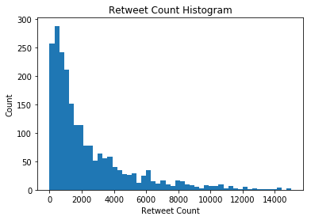

```python
plt.hist(master_tweeter_data['retweet_count'],range=[0, 15000], bins=50)
plt.xlabel('Retweet Count')
plt.ylabel('Count')
plt.title('Retweet Count Histogram');
```

This plot is skewed right with most post having a relative low amount of retweets.